# Problema 4 - checkpoint 1

```r
knitr::opts_chunk$set(echo=TRUE, warning=FALSE, message=FALSE, fig.width=12, fig.height=6)
```

Para essa parte do problema usaremos dados sobre avaliações de filmes: http://grouplens.org/datasets/movielens/latest/

```r
filmes = read.csv("dados/movies.csv",  encoding="UTF-8")
ratings = read.csv("dados/ratings.csv",  encoding="UTF-8")
```

#### 1 - Escolha uma trilogia (ou uma n-logia com n > 3) e avalie para qual dos episódios da trilogia há melhor avaliação e para qual há mais variação nas notas atribuídas ao filme.

Para a primeira parte, iremos escolher a trilogia Senhor dos Anéis.

```r
filmes.senhor.dos.aneis = filmes %>%
  filter(grepl('Lord of the Rings', title))

senhor.dos.aneis.ratings = ratings %>%
   filter(movieId %in% filmes.senhor.dos.aneis$movieId)

head(filmes.senhor.dos.aneis)
```

```
##   movieId                                                     title
## 1    2116                             Lord of the Rings, The (1978)
## 2    4993 Lord of the Rings: The Fellowship of the Ring, The (2001)
## 3    5952             Lord of the Rings: The Two Towers, The (2002)
## 4    7153     Lord of the Rings: The Return of the King, The (2003)
##                                 genres
## 1 Adventure|Animation|Children|Fantasy
## 2                    Adventure|Fantasy
## 3                    Adventure|Fantasy
## 4       Action|Adventure|Drama|Fantasy
```

Na seleção da trilogia, descobrimos um filme inesperado “The Lord of the Rings (1978)”, filme americano de 1978, criado e realizado por Ralph Bakshi. A longa metragem é uma adaptação da primeira parte da trilogia “O Senhor dos Anéis”(1954-1955) e foi feita por Peter S. Beagle e Chris Conkling. O filme contém animação e cenas live-action utilizando a técnica rotoscoped para dar-lhe uma aparência mais consistente e real a toda a acção do filme.

Iremos verificar a quantidade de avaliações que cada filme teve

```r
senhor.dos.aneis.ratings.quant = senhor.dos.aneis.ratings %>%
group_by(movieId) %>%
summarise(quantidade = n())

head(senhor.dos.aneis.ratings.quant)
```

```
## # A tibble: 4 x 2
##   movieId quantidade
##     <int>      <int>
## 1    2116         19
## 2    4993        189
## 3    5952        167
## 4    7153        166
```

Como podemos verificar, o filme de 1978 possui 19 avaliações, e considerando que não faz parte da trilogia (2001 a 2003), vamos retirá-lo da análise. E verificaremos a distribuição da amostra.

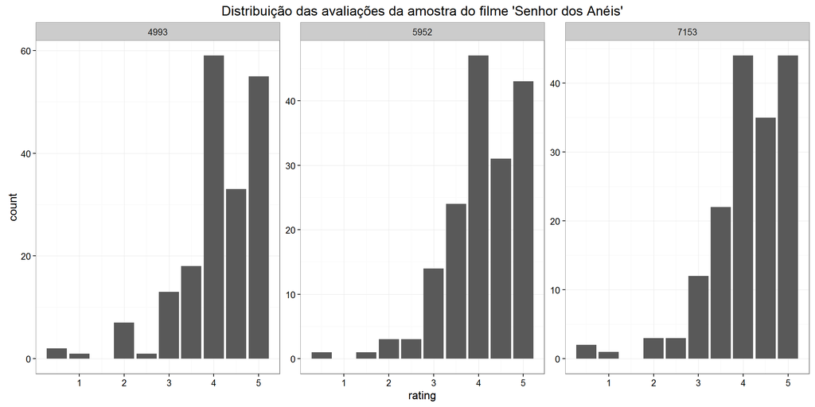

```r
senhor.dos.aneis.ratings = senhor.dos.aneis.ratings %>%
  filter(movieId != 2116)

ggplot(senhor.dos.aneis.ratings, aes(rating)) +
  geom_bar() +
  facet_wrap(~movieId, scales = c("free_y")) +
  ggtitle("Distribuição das avaliações da amostra do filme 'Senhor dos Anéis'")
```

A distribuição das avaliações dos usuários é parecida, concentrando em sua maior parte à direita. E para uma maior representação, decidimos utilizar o intervalo de confiança feito com a média dos valores.

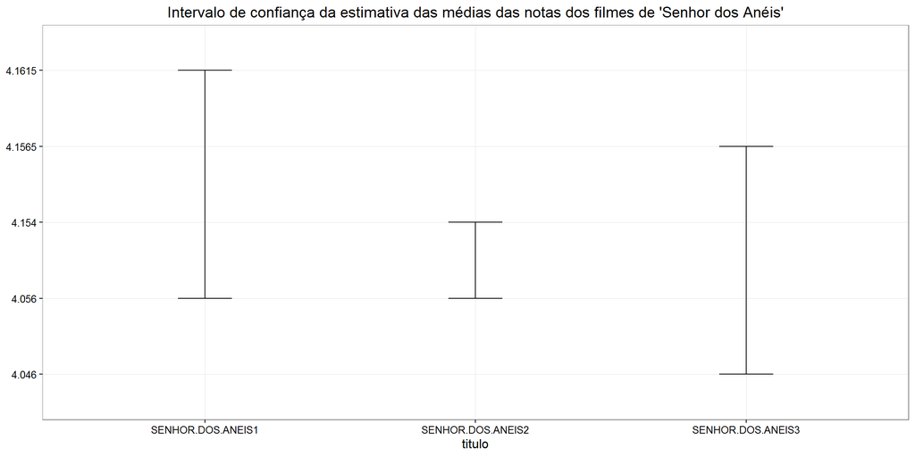

```r
#Lord of the Rings: The Fellowship of the Ring, The (2001)
experimento1 = sample_n(filter(senhor.dos.aneis.ratings, movieId == 4993), 1000, replace = TRUE)

bootstrap.media.senhor.dos.aneis1 = bootstrap(experimento1, mean(rating))
media.senhor.dos.aneis1 = CI.bca(bootstrap.media.senhor.dos.aneis1, probs = c(.025, .975))


# Lord of the Rings: The Two Towers, The (2002)
experimento2 = sample_n(filter(senhor.dos.aneis.ratings, movieId == 5952), 1000, replace = TRUE)

bootstrap.media.senhor.dos.aneis2 = bootstrap(experimento2, mean(rating))
media.senhor.dos.aneis2 = CI.bca(bootstrap.media.senhor.dos.aneis2, probs = c(.025, .975))


# Lord of the Rings: The Return of the King, The (2003)
experimento3 = sample_n(filter(senhor.dos.aneis.ratings, movieId == 7153), 1000, replace = TRUE)

bootstrap.media.senhor.dos.aneis3 = bootstrap(experimento3, mean(rating))
media.senhor.dos.aneis3 = CI.percentile(bootstrap.media.senhor.dos.aneis3, probs = c(.025, .975))


medias.senhor.dos.aneis = data.frame(
  rbind(
    c("SENHOR.DOS.ANEIS1", media.senhor.dos.aneis1),
    c("SENHOR.DOS.ANEIS2", media.senhor.dos.aneis2),
    c("SENHOR.DOS.ANEIS3", media.senhor.dos.aneis3)
  )
)

names(medias.senhor.dos.aneis) = c("titulo", "limite.inferior", "limite.superior")

medias.senhor.dos.aneis %>%
  ggplot(aes(x = titulo, ymin = limite.inferior, ymax = limite.superior)) +
  geom_errorbar(width = .2) +
    ggtitle("Intervalo de confiança da estimativa das médias das notas dos filmes de 'Senhor dos Anéis'")
```

Como conclusão à pergunta inicial ‘Qual dos episódios da trilogia há melhor avaliação’: Não podemos inferir com certeza qual o melhor filme da trilogia, visto que o intervalo de confiança da média das avaliações das amostras se sobrepõe.

Para a segunda parte da pergunta (quanto a variação das notas), iremos determinar o intervalo de confiança para a variação nas notas atribuídas ao filme.

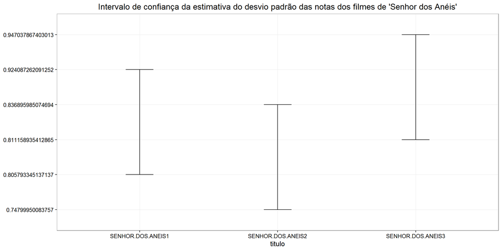

```r
#Lord of the Rings: The Fellowship of the Ring, The (2001)

bootstrap.sd.senhor.dos.aneis1 = bootstrap(experimento1, sd(rating))
sd.senhor.dos.aneis1 = CI.bca(bootstrap.sd.senhor.dos.aneis1, probs = c(.025, .975))

# Lord of the Rings: The Two Towers, The (2002)

bootstrap.sd.senhor.dos.aneis2 = bootstrap(experimento2, sd(rating))
sd.senhor.dos.aneis2 = CI.bca(bootstrap.sd.senhor.dos.aneis2, probs = c(.025, .975))

# Lord of the Rings: The Return of the King, The (2003)

bootstrap.sd.senhor.dos.aneis3 = bootstrap(experimento3, sd(rating))
sd.senhor.dos.aneis3 = CI.percentile(bootstrap.sd.senhor.dos.aneis3, probs = c(.025, .975))

sd.senhor.dos.aneis <- data.frame(
  rbind(
    c("SENHOR.DOS.ANEIS1", sd.senhor.dos.aneis1),
    c("SENHOR.DOS.ANEIS2", sd.senhor.dos.aneis2),
    c("SENHOR.DOS.ANEIS3", sd.senhor.dos.aneis3)
  )
)

names(sd.senhor.dos.aneis) = c("titulo", "limite.inferior", "limite.superior")

sd.senhor.dos.aneis %>%
  ggplot(aes(x = titulo, ymin = limite.inferior, ymax = limite.superior)) +
  geom_errorbar(width = .2) +
    ggtitle("Intervalo de confiança da estimativa do desvio padrão das notas dos filmes de 'Senhor dos Anéis'")
```

Também não é possível inferir sobre qual filme possui maior variabilidade.

#### 2- Normalmente os filmes têm vários gêneros. Existe uma relação entre em quantos gêneros os filmes se encaixam e a avaliação que os filmes recebem? Mais especificamente: se consideramos a os filmes com 1, 2, 3 … gêneros, existe alguma quantidade de gêneros num mesmo filme que em geral recebe avaliações melhores? Caso exista, estime a diferença entre essa combinação e filmes com apenas um gênero. (Repare que você terá que escolher que medida você comparará: média, mediana, etc.)

```r
generos = read.csv("dados/movie-genre.csv",  encoding="UTF-8")
```

Por ser uma quantidade maior de dados e a provável assimetria dos dados de avaliações, iremos utilizar a mediana como forma de comparação.

```r
mediana.generos = data.frame(movieId=numeric(0), n=numeric(0), mediana=numeric(0))

quantidade.genero.filme = generos %>%
  group_by(title) %>%
  summarise(quantidade.generos = n())

quantidade.genero.filme = merge(quantidade.genero.filme, filmes, by=c("title","title"))

quantidade.genero.filme = quantidade.genero.filme %>%
  select(movieId, title, quantidade.generos) %>%
  arrange(quantidade.generos)
```

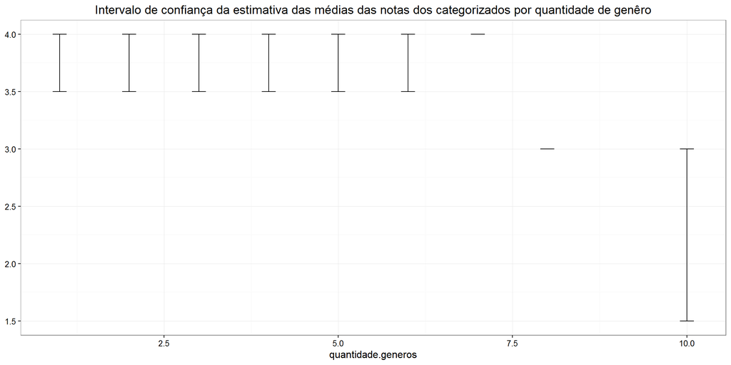

```r
grupo.genero = function(quantidade.genero){
  filmes.quantidade.genero = quantidade.genero.filme %>%
    filter(quantidade.generos == quantidade.genero)

  ratings.quantidade.genero = ratings %>%
        filter(movieId %in% filmes.quantidade.genero$movieId)

  return(ratings.quantidade.genero)
}

boot = function(df= ratings){
  experimento = sample_n(df, 1000, replace = TRUE)
  bootstrap.mediana = bootstrap(experimento, median(rating))
  mediana = CI.percentile(bootstrap.mediana, probs = c(.025, .975))
  return(mediana)
}

#filmes com 1 genêro
df.1.genero = grupo.genero(1)
mediana.1.genero = boot(df.1.genero)

#filmes com 2 genêros
df.2.generos = grupo.genero(2)
mediana.2.generos = boot(df.2.generos)

#filmes com 3 genêros
df.3.generos = grupo.genero(3)
mediana.3.generos = boot(df.3.generos)

#filmes com 4 genêros
df.4.generos = grupo.genero(4)
mediana.4.generos = boot(df.4.generos)

#filmes com 5 genêros
df.5.generos = grupo.genero(5)
mediana.5.generos = boot(df.5.generos)

#filmes com 6 genêros
df.6.generos = grupo.genero(6)
mediana.6.generos = boot(df.6.generos)

#filmes com 7 genêros
df.7.generos = grupo.genero(7)
mediana.7.generos = boot(df.7.generos)

#filmes com 8 genêros
df.8.generos = grupo.genero(8)
mediana.8.generos = boot(df.8.generos)

#filmes com 10 genêros
df.10.generos = grupo.genero(10)
mediana.10.generos = boot(df.10.generos)

medianas.filmes.por.genero = data.frame(
  rbind(mediana.1.genero,
        mediana.2.generos,
        mediana.3.generos,
        mediana.4.generos,
        mediana.5.generos,
        mediana.6.generos,
        mediana.7.generos,
        mediana.8.generos,
        mediana.10.generos))

medianas.filmes.por.genero = mutate(medianas.filmes.por.genero, quantidade.generos = c(1,2,3,4,5,6,7,8,10))

names(medianas.filmes.por.genero) = c("limite.inferior", "limite.superior", "quantidade.generos")

medianas.filmes.por.genero %>%
  ggplot(aes(x = quantidade.generos, ymin = limite.inferior, ymax = limite.superior)) +
  geom_errorbar(width = .2) +
    ggtitle("Intervalo de confiança da estimativa das médias das notas dos categorizados por quantidade de genêro")
```